# LoanInterestRatePrediction_ANambiar

Ankita Nambiar, 2/13/2023

-- For UChicago Analytics class. Do Not Replicate

```python
%matplotlib inline
import numpy as np
import pandas as pd
from scipy import stats
import matplotlib.pyplot as plt
import seaborn as sns
from sklearn.model_selection import train_test_split
# Importing Classifier Modules
from sklearn.linear_model import LogisticRegression
from sklearn.svm import SVC, LinearSVC
from sklearn.neighbors import KNeighborsClassifier
from sklearn.tree import DecisionTreeClassifier
from sklearn.ensemble import RandomForestClassifier
from sklearn.naive_bayes import GaussianNB
from sklearn.linear_model import Perceptron
from sklearn.linear_model import SGDClassifier
from sklearn.ensemble import GradientBoostingClassifier
```

```python
pd.set_option('display.max_rows', 60)
```

```python
import warnings
warnings.filterwarnings("ignore")
```

# Load Data

```python
df_1 = pd.read_csv('Data for Cleaning & Modeling.csv')
df_1.head()
```

|  | X1 | X2 | X3 | X4 | X5 | X6 | X7 | X8 | X9 | X10 | ... | X23 | X24 | X25 | X26 | X27 | X28 | X29 | X30 | X31 | X32 |
| --- | --- | --- | --- | --- | --- | --- | --- | --- | --- | --- | --- | --- | --- | --- | --- | --- | --- | --- | --- | --- | --- |
| 0 | 11.89% | 54734.0 | 80364.0 | $25,000 | $25,000 | $19,080 | 36 months | B | B4 | NaN | ... | Feb-94 | 0.0 | NaN | NaN | 10.0 | 0.0 | 28854.0 | 52.10% | 42.0 | f |
| 1 | 10.71% | 55742.0 | 114426.0 | $7,000 | $7,000 | $673 | 36 months | B | B5 | CNN | ... | Oct-00 | 0.0 | NaN | NaN | 7.0 | 0.0 | 33623.0 | 76.70% | 7.0 | f |
| 2 | 16.99% | 57167.0 | 137225.0 | $25,000 | $25,000 | $24,725 | 36 months | D | D3 | Web Programmer | ... | Jun-00 | 0.0 | 41.0 | NaN | 10.0 | 0.0 | 19878.0 | 66.30% | 17.0 | f |
| 3 | 13.11% | 57245.0 | 138150.0 | $1,200 | $1,200 | $1,200 | 36 months | C | C2 | city of beaumont texas | ... | Jan-85 | 0.0 | 64.0 | NaN | 5.0 | 0.0 | 2584.0 | 40.40% | 31.0 | f |
| 4 | 13.57% | 57416.0 | 139635.0 | $10,800 | $10,800 | $10,692 | 36 months | C | C3 | State Farm Insurance | ... | Dec-96 | 1.0 | 58.0 | NaN | 14.0 | 0.0 | 3511.0 | 25.60% | 40.0 | f |

5 rows × 32 columns

# Initial Data Anaysis and Cleaning

```python
df_1.shape
```

```
(400000, 32)
```

```python
df_1.info()
```

```
<class 'pandas.core.frame.DataFrame'>
RangeIndex: 400000 entries, 0 to 399999
Data columns (total 32 columns):
 #   Column  Non-Null Count   Dtype
---  ------  --------------   -----
 0   X1      338990 non-null  object
 1   X2      399999 non-null  float64
 2   X3      399999 non-null  float64
 3   X4      399999 non-null  object
 4   X5      399999 non-null  object
 5   X6      399999 non-null  object
 6   X7      399999 non-null  object
 7   X8      338730 non-null  object
 8   X9      338730 non-null  object
 9   X10     376014 non-null  object
```

[output cut: 24 more lines]

### Convert variables to more appropriate Types + make cleaner.

```python
# convert X1 into float type, still in percentage
df_1['X1'] = df_1['X1'].str.rstrip("%").astype(float)

# convert X30 into float type, still in percentage
df_1['X30'] = df_1['X30'].str.rstrip("%").astype(float)

# convert X4, X5, X6 into float type from string, still in dollara
df_1['X4'] = df_1['X4'].replace('[\$,]', '', regex=True).astype(float)
df_1['X5'] = df_1['X5'].replace('[\$,]', '', regex=True).astype(float)
df_1['X6'] = df_1['X6'].replace('[\$,]', '', regex=True).astype(float)

# convert X7 into int type from string
df_1['X7'] = df_1['X7'].str.extract('(\d+)', expand=False)
df_1['X7'] = df_1['X7'].astype(float)
```

### Target Value : X1

```python
df_1['X1'].describe()
```

```
count    338990.000000
mean         13.946271
std           4.377951
min           5.420000
25%          10.990000
50%          13.680000
75%          16.780000
max          26.060000
Name: X1, dtype: float64
```

#### Drop all of Null X1 Values since this is our target value. Need to be as accurate as possible for the target, so do not predict.

```python
df = df_1.dropna(axis=0, subset=['X1'])
```

# EDA, Feature Engineering

### X2, X3

#### X2 and X3 is not needed and will not give information on interest rate. They are ID numbers, drop.

```python
df = df.drop(['X2'], axis =1)
df = df.drop(['X3'], axis =1)
```

### X4

#### Only one null, replace with mean since it is a float type. this will be repeated throughout the notebook for int/ float types with only 1 null value.

```python
mean_value=df['X4'].mean()
df['X4'].fillna(value=mean_value, inplace=True)
```

```python
df['X4'].describe()
```

```
count    338990.000000
mean      14276.968353
std        8252.251932
min         500.000000
25%        8000.000000
50%       12000.000000
75%       20000.000000
max       35000.000000
Name: X4, dtype: float64
```

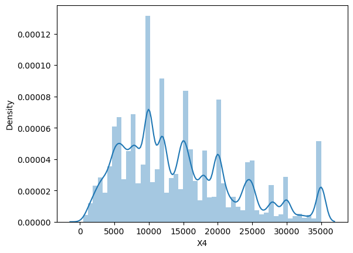

```python
sns.distplot(df[df['X4'].notnull()]['X4'])
```

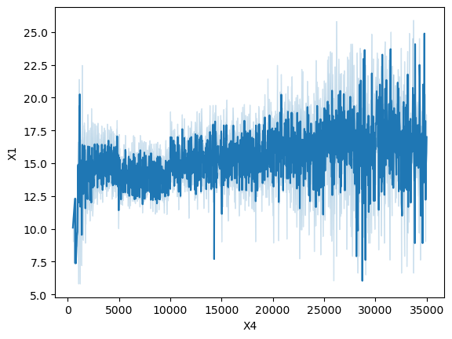

```python
sns.lineplot(x="X4", y="X1", data=df)
plt.show()
```

#### Turn continuous variable into categorical, as it is better for presenting data and making it cleaner. Different bins created based on shifts in X1.

```python
bins = [0, 1000, 5000, 10000, 15000, 20000, 25000, 28000]
labels = ['loanrequest_1000', 'loanrequest_5000', 'loanrequest_10000', 'loanrequest_15000',
         'loanrequest_20000', 'loanrequest_25000', 'loanrequest_28000']
df['loanrequest_categories'] = pd.cut(df['X4'], bins=bins, labels=labels)
dummy_df = pd.get_dummies(df['loanrequest_categories'])
df = pd.concat([df, dummy_df], axis=1)
df = df.drop('loanrequest_categories', axis=1)
```

### X5

#### Only one null, replace with mean since it is a float type.

```python
mean_value=df['X5'].mean()
df['X5'].fillna(value=mean_value, inplace=True)
```

```python
df['X5'].describe()
```

```
count    338990.000000
mean      14248.306140
std        8238.052185
min         500.000000
25%        8000.000000
50%       12000.000000
75%       20000.000000
max       35000.000000
Name: X5, dtype: float64
```

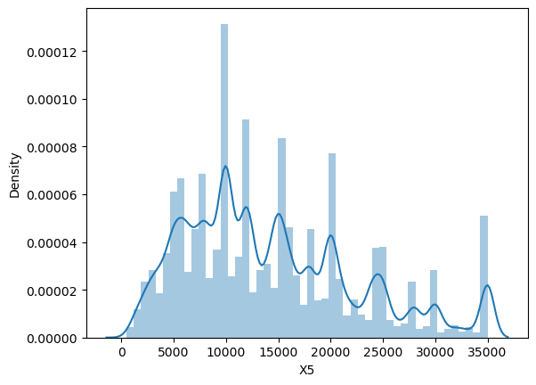

```python
sns.distplot(df[df['X5'].notnull()]['X5'])
```

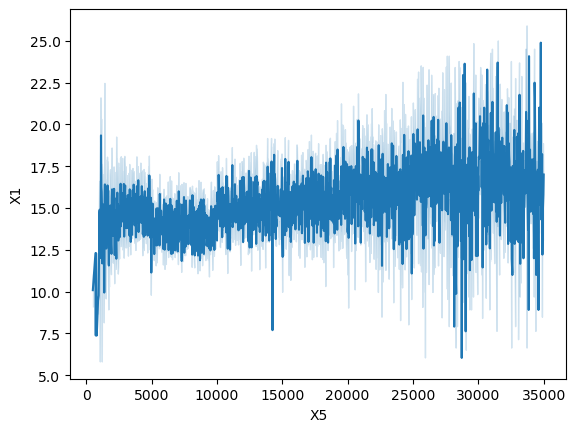

```python
sns.lineplot(x="X5", y="X1", data=df)
plt.show()
```

#### This is the same distirbution in the lineplot as the lineplot for X4 vs X1. Not helpful since we have that already. Will be dropping

#### Instead, a new column for the percent funded might be helpful:

### new col = %_funded = X5/ X4

```python
df['%_funded'] = df['X5'] / df['X4'] * 100
```

```python
df['%_funded'].describe()
```

```
count    338990.000000
mean         99.849327
std           2.326777
min          10.250000
25%         100.000000
50%         100.000000
75%         100.000000
max         100.000000
Name: %_funded, dtype: float64
```

```python
#sns.lineplot(x="%_funded", y="X1", data=df)
#plt.xlim(10, 60)
#plt.show()
```

#### Keep as continuous variable. Too many shifts to make into a categorical variables.

```python
df = df.drop(['X4'], axis =1)
```

### X6

#### Missing one variable + is a float. Replace with mean.

```python
mean_value=df['X6'].mean()
df['X6'].fillna(value=mean_value, inplace=True)
```

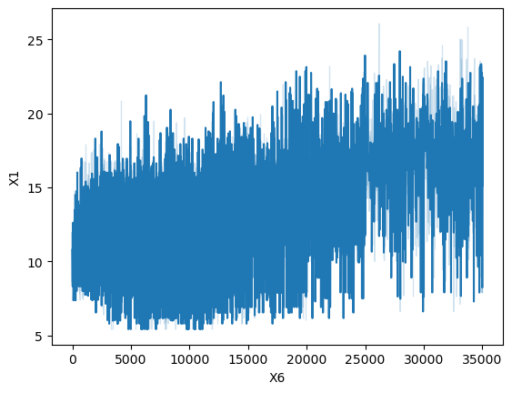

```python
sns.lineplot(x="X6", y="X1", data=df)
plt.show()
```

```python
#sns.lineplot(x="X6", y="X1", data=df)
#plt.xlim(25000, 30000)
#plt.show()
```

#### Turn continuous variable into categorical, as it is better for presenting data and making it cleaner. Different bins created based on shifts in X1. For X6, there are 6 main shifts.

```python
bins = [0, 5000, 15000, 20000, 25000, 28000, 30000]
labels = ['ivfunded_5000', 'ivfunded_15000', 'ivfunded_20000',
          'ivfunded_25000','ivfunded_28000', 'ivfunded_30000']
df['ivfunded_categories'] = pd.cut(df['X6'], bins=bins, labels=labels)
dummy_df = pd.get_dummies(df['ivfunded_categories'])
df = pd.concat([df, dummy_df], axis=1)
df = df.drop('ivfunded_categories', axis=1)
```

#### Could be helpful to create a new column called % investor funded based on the last 2 columns:

### new col = %_inv_funded = X6/ X5

```python
df['%_inv_funded'] = df['X6'] / df['X5'] * 100
# df.head()
```

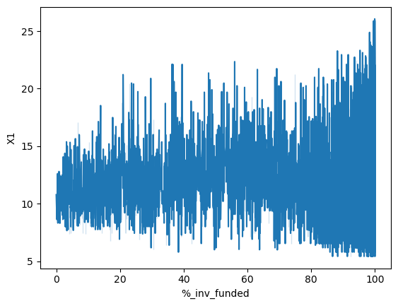

```python
sns.lineplot(x="%_inv_funded", y="X1", data=df)
plt.show()
```

#### Divide into 5 bins.

```python
bins = [0, 20, 40, 60, 80, 100]
labels = ['%_inv_funded_20', '%_inv_funded_40', '%_inv_funded_60',
         '%_inv_funded_80', '%_inv_funded_100']
df['%_inv_funded_categories'] = pd.cut(df['%_inv_funded'], bins=bins, labels=labels)
dummy_df = pd.get_dummies(df['%_inv_funded_categories'])
df = pd.concat([df, dummy_df], axis=1)

df = df.drop('%_inv_funded_categories', axis=1)
df = df.drop(['%_inv_funded'], axis =1)
df = df.drop(['X6'], axis =1)
df = df.drop(['X5'], axis =1)
```

### X7

```python
df['X7'].mode()
```

```
0    36.0
Name: X7, dtype: float64
```

```python
df['X7'].fillna(value=36.0, inplace=True)
```

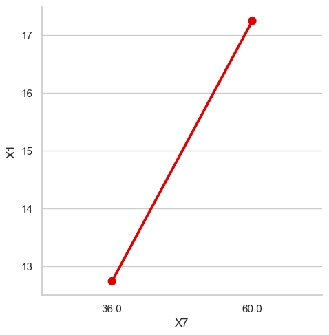

```python
sns.set(style="whitegrid")
g = sns.PairGrid(data=df, x_vars=['X7'], y_vars='X1', height=5)
g.map(sns.pointplot, color=sns.xkcd_rgb["red"])
```

#### There is a relation between X7 on X1. when X7 = 60, there is a higher X1. include in model. Create a dummy variable for cleaner df.

### new dummy variable: is_60forNofPayments:, drop X7

```python
df['is_60forNofPayments'] = df['X7'].apply(lambda x: 1 if x == 60.0 else 0)
df = df.drop(['X7'], axis =1)
```

### X8

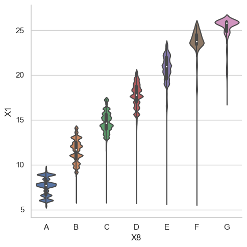

```python
sns.catplot(
    data=df, x="X8", y="X1",  kind="violin",
    order=[ "A", "B", "C", "D", "E", "F", "G"]
)
```

#### There is X9 which is similar to X8 but with more detail. Also, X9 has a strong relation with X1 (seen below), so drop X8.

```python
df = df.drop(['X8'], axis=1)
```

### X9

```python
df['X9'].unique()
```

```
array(['B4', 'B5', 'D3', 'C2', 'C3', 'D4', 'B3', 'C5', 'A5', 'D2', 'B1',
       'C4', 'A4', 'A3', 'C1', 'E4', 'B2', 'A2', 'E2', 'E1', 'D1', 'F1',
       'F2', 'A1', 'F3', 'E5', 'D5', nan, 'E3', 'F4', 'G5', 'F5', 'G1',
       'G4', 'G3', 'G2'], dtype=object)
```

```python
x9cols = [ "A1", "A2", "A3", "A4", "A5",
            "B1", "B2", "B3", "B4", "B5",
            "C1", "C2", "C3", "C4", "C5",
            "D1", "D2", "D3", "D4", "D5",
            "E1", "E2", "E3", "E4", "E5",
            "F1", "F2", "F3", "F4", "F5",
            "G1", "G2", "G3", "G4", "G5"
            ]
```

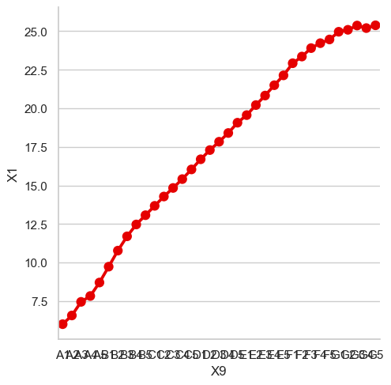

```python
sns.set(style="whitegrid")
g = sns.PairGrid(data=df, x_vars=['X9'], y_vars='X1', height=5)
g.map(sns.pointplot, color=sns.xkcd_rgb["red"], order = x9cols)
```

#### Create a new column that has the loan subgrades in numerical value. A1 = 1, A2 =2, ...

```python
df = df.replace({'X9': {'A1': 1, 'A2': 2, 'A3': 3, 'A4': 4,'A5': 5,
                        'B1': 6, 'B2': 7, 'B3': 8, 'B4': 9,'B5': 10,
                        'C1': 11, 'C2': 12, 'C3': 13, 'C4': 14,'C5': 15,
                        'D1': 16, 'D2': 17, 'D3': 18, 'D4': 19,'D5': 20,
                        'E1': 21, 'E2': 22, 'E3': 23, 'E4': 24,'E5':25,
                        'F1': 26, 'F2': 27, 'F3': 28, 'F4': 29,'F5':30,
                        'G1': 31, 'G2': 32, 'G3': 33, 'G4': 34,'G5':35
                       }})
```

#### Turned into integers and interpolated. This is fine because X9 has an approximately linear relation with X1.

```python
df['X9']= df['X9'].interpolate()
df['X9'] = df['X9'].astype(int)
```

```python
df['X9'].describe()
```

```
count    338990.000000
mean         12.005932
std           6.289032
min           1.000000
25%           7.000000
50%          11.000000
75%          16.000000
max          35.000000
Name: X9, dtype: float64
```

### X10

```python
df['X10'].describe()
```

```
count      318733
unique     163395
top       Teacher
freq         3602
Name: X10, dtype: object
```

```python
df['X10'].info
```

```
<bound method Series.info of 0                                       NaN
1                                       CNN
2                            Web Programmer
3                    city of beaumont texas
4                      State Farm Insurance
                        ...
399995             Administrative Assistant
399996                               helper
399997               Facility Administrator
399998    Senior Creative Designer/Ad Sales
399999                          Electrician
Name: X10, Length: 338990, dtype: object>
```

#### Drop X10 (job) since the later variables have income and verification of income. This is the important part of the job variable.

```python
df = df.drop(['X10'], axis =1)
```

### X11

```python
df['X11'].unique()
```

```
array(['< 1 year', '1 year', '10+ years', '6 years', '9 years', '3 years',
       '5 years', '2 years', '4 years', '8 years', '7 years', nan],
      dtype=object)
```

#### Convert X11 into int type from string

```python
df = df.replace({'X11': {'< 1 year':0, '1 year' :1, '10+ years':10,
                         '6 years':6, '9 years':9, '3 years':3,
                       '5 years':5, '2 years':2, '4 years':4,
                         '8 years':8, '7 years':7
                        }})
```

#### num of years is numerical, so interpolate.

```python
df['X11']= df['X11'].interpolate()
df['X11'].describe()
```

```
count    338990.000000
mean          5.996767
std           3.574860
min           0.000000
25%           3.000000
50%           6.000000
75%          10.000000
max          10.000000
Name: X11, dtype: float64
```

```python
df['X11']= df['X11'].astype(int)
```

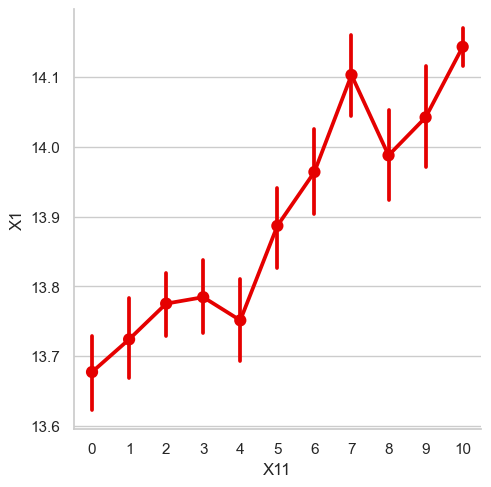

```python
sns.set(style="whitegrid")
g = sns.PairGrid(data=df, x_vars=['X11'], y_vars='X1', height=5)
g.map(sns.pointplot, color=sns.xkcd_rgb["red"])
```

#### make x11 simpler by creating dummy variable

### new dummy variable: 'is_in_early-career', drop 'X11'

```python
bins = [0, 6]
labels = ['is_in_early-career']
df['career_age_categories'] = pd.cut(df['X11'], bins=bins, labels=labels)

dummy_df = pd.get_dummies(df['career_age_categories'])
df = pd.concat([df, dummy_df], axis=1)
df = df.drop('career_age_categories', axis=1)
```

```python
df = df.drop('X11', axis=1)
```

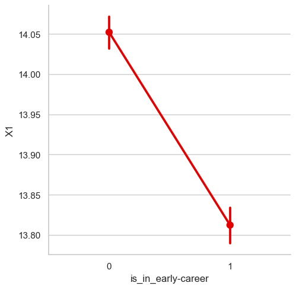

```python
sns.set(style="whitegrid")
g = sns.PairGrid(data=df, x_vars=['is_in_early-career'], y_vars='X1', height=5)
g.map(sns.pointplot, color=sns.xkcd_rgb["red"])
```

### X12

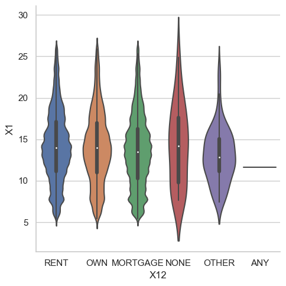

```python
sns.catplot(
    data=df, x="X12", y="X1",  kind="violin"
)
```

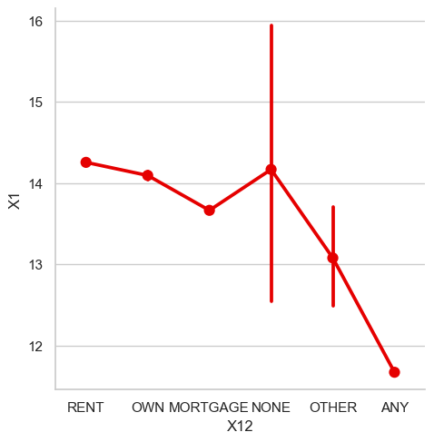

```python
sns.set(style="whitegrid")
g = sns.PairGrid(data=df, x_vars=['X12'], y_vars='X1', height=5)
g.map(sns.pointplot, color=sns.xkcd_rgb["red"])
```

```python
df['X12'].info()
```

```
<class 'pandas.core.series.Series'>
Int64Index: 338990 entries, 0 to 399999
Series name: X12
Non-Null Count   Dtype
--------------   -----
287030 non-null  object
dtypes: object(1)
memory usage: 5.2+ MB
```

```python
df['X12'].describe()
```

```
count       287030
unique           6
top       MORTGAGE
freq        145958
Name: X12, dtype: object
```

### Categorical variable with many missing values. Use KNN, a supervised learning method, to predict the missing valuess, given the others.

## X13

```python
df['X13'].info()
```

```
<class 'pandas.core.series.Series'>
Int64Index: 338990 entries, 0 to 399999
Series name: X13
Non-Null Count   Dtype
--------------   -----
287238 non-null  float64
dtypes: float64(1)
memory usage: 5.2 MB
```

```python
287238/338990
```

```
0.8473347296380425
```

### interpolate for null values since it is continuous.

```python
df['X13']= df['X13'].interpolate()
```

```python
df['X13'].describe()
```

```
count    3.389900e+05
mean     7.311112e+04
std      5.369891e+04
min      3.000000e+03
25%      4.600000e+04
50%      6.400000e+04
75%      8.750000e+04
max      7.500000e+06
Name: X13, dtype: float64
```

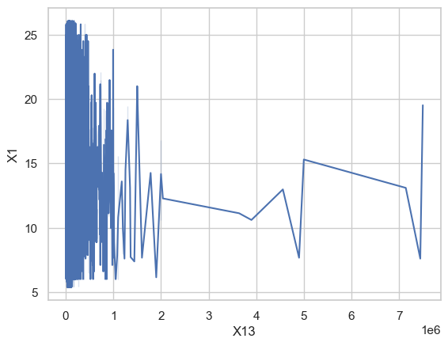

```python
sns.lineplot(x="X13", y="X1", data=df)
plt.show()
```

### X14

```python
df['X14'].info()
```

```
<class 'pandas.core.series.Series'>
Int64Index: 338990 entries, 0 to 399999
Series name: X14
Non-Null Count   Dtype
--------------   -----
338989 non-null  object
dtypes: object(1)
memory usage: 5.2+ MB
```

```python
df['X14'].unique()
```

```
array(['VERIFIED - income', 'not verified', 'VERIFIED - income source',
       nan], dtype=object)
```

```python
df['X14'].mode()
```

```
0    VERIFIED - income
Name: X14, dtype: object
```

```python
df['X14'].fillna(value="VERIFIED - income", inplace=True)
```

#### replace with mode because only one null and is a string type.

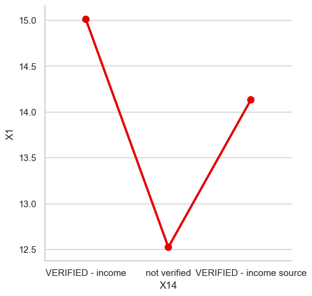

```python
sns.set(style="whitegrid")
g = sns.PairGrid(data=df, x_vars=['X14'], y_vars='X1', height=5)
g.map(sns.pointplot, color=sns.xkcd_rgb["red"])
```

### 3 new dummy variables for verified income, drop X14

```python
cat_variables = df[['X14']]
cat_dummies = pd.get_dummies(cat_variables, prefix=['is_'])
```

```python
df = pd.concat([df, cat_dummies], axis=1)
df = df.rename(columns={'is__VERIFIED - income': 'is_income_verified',
                        'is__VERIFIED - income source': 'is_income_source_verified',
                        'is__not verified': 'is_income_not_verified'
                       })
df = df.drop('X14', axis=1)
```

### X15

```python
df['X15'].info()
```

```
<class 'pandas.core.series.Series'>
Int64Index: 338990 entries, 0 to 399999
Series name: X15
Non-Null Count   Dtype
--------------   -----
338989 non-null  object
dtypes: object(1)
memory usage: 5.2+ MB
```

```python
df['X15'].mode()
```

```
0    Jul-14
Name: X15, dtype: object
```

```python
df['X15'].fillna(value = "Jul-14", inplace=True)
```

### split X15 date into month and year

```python
df[['month_loanIssued', 'year__loanIssued']] = df['X15'].str.split('-', expand=True)
df['year__loanIssued'] = df['year__loanIssued'].astype(int)
```

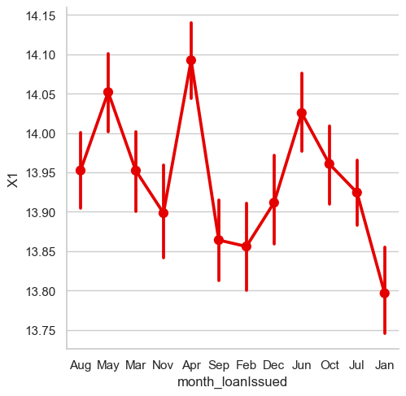

```python
sns.set(style="whitegrid")
g = sns.PairGrid(data=df, x_vars=['month_loanIssued'], y_vars='X1', height=5)
g.map(sns.pointplot, color=sns.xkcd_rgb["red"])
```

```python
df["month_loanIssued"].unique()
```

```
array(['Aug', 'May', 'Mar', 'Nov', 'Apr', 'Sep', 'Feb', 'Dec', 'Jun',
       'Oct', 'Jul', 'Jan'], dtype=object)
```

### create dummy since month seems to have a pattern: loanIssued_

```python
cat_variables = df[['month_loanIssued']]
cat_dummies = pd.get_dummies(cat_variables, prefix=['loanIssued_'])
cat_dummies.head()
df = pd.concat([df, cat_dummies], axis=1)
```

##### keep as numerical, as the linear-like pattern could be important to keep

```python
df = df.drop('X15', axis=1)
```

```python
df = df.drop('month_loanIssued', axis=1)
```

### X16

```python
df['X16'].info()
```

```
<class 'pandas.core.series.Series'>
Int64Index: 338990 entries, 0 to 399999
Series name: X16
Non-Null Count   Dtype
--------------   -----
105056 non-null  object
dtypes: object(1)
memory usage: 5.2+ MB
```

```python
105056 / 338990
```

```
0.3099088468686392
```

#### Very little data in column. Drop. Not helpful.

```python
df = df.drop(['X16'], axis =1)
```

### X17

```python
df['X17'].info()
```

```
<class 'pandas.core.series.Series'>
Int64Index: 338990 entries, 0 to 399999
Series name: X17
Non-Null Count   Dtype
--------------   -----
338989 non-null  object
dtypes: object(1)
memory usage: 5.2+ MB
```

#### One null, string type. Replace with mode.

```python
df['X17'].mode()
```

```
0    debt_consolidation
Name: X17, dtype: object
```

```python
df['X17'].fillna(value="debt_consolidation", inplace=True)
```

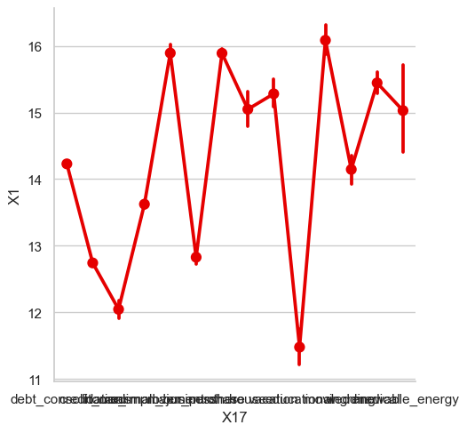

```python
sns.set(style="whitegrid")
g = sns.PairGrid(data=df, x_vars=['X17'], y_vars='X1', height=5)
g.map(sns.pointplot, color=sns.xkcd_rgb["red"])
```

```python
df['X17'].unique()
```

```
array(['debt_consolidation', 'credit_card', 'car', 'home_improvement',
       'small_business', 'major_purchase', 'other', 'house', 'vacation',
       'educational', 'moving', 'wedding', 'medical', 'renewable_energy'],
      dtype=object)
```

### 14 new dummy from loan category, drop X17

```python
cat_variables = df[['X17']]
cat_dummies = pd.get_dummies(cat_variables, prefix=['category_is_'])
df = pd.concat([df, cat_dummies], axis=1)
df = df.drop('X17', axis=1)
```

### X18

```python
df['X18'].info()
```

```
<class 'pandas.core.series.Series'>
Int64Index: 338990 entries, 0 to 399999
Series name: X18
Non-Null Count   Dtype
--------------   -----
338973 non-null  object
dtypes: object(1)
memory usage: 5.2+ MB
```

```python
df['X18'].unique()
```

```
array(['Debt consolidation for on-time payer', 'Credit Card payoff',
       'mlue', ..., 'debt paid in full ', 'STAPLES',
       'Credit CardConsolidation'], dtype=object)
```

#### Same information as X17 but not as clean. Drop.

```python
df = df.drop(['X18'], axis =1)
```

### X19

```python
df['X19'].info()
```

```
<class 'pandas.core.series.Series'>
Int64Index: 338990 entries, 0 to 399999
Series name: X19
Non-Null Count   Dtype
--------------   -----
338989 non-null  object
dtypes: object(1)
memory usage: 5.2+ MB
```

### Zip code will more than likely will not provide useful information. Drop.

```python
df = df.drop(['X19'], axis =1)
```

## X20

```python
df['X20'].unique()
```

```
array(['CA', 'NY', 'TX', 'CT', 'RI', 'MD', 'MA', 'MI', 'KY', 'MS', 'KS',
       'GA', 'NC', 'WA', 'OH', 'AZ', 'IL', 'CO', 'WI', 'FL', 'IN', 'VA',
       'ME', 'NJ', 'NE', 'NM', 'MO', 'UT', 'LA', 'SC', 'AL', 'TN', 'NH',
       'SD', 'DE', 'WY', 'OR', 'MN', 'DC', 'NV', 'IA', 'PA', 'AR', 'VT',
       'OK', 'ID', 'AK', 'MT', 'HI', 'WV', nan], dtype=object)
```

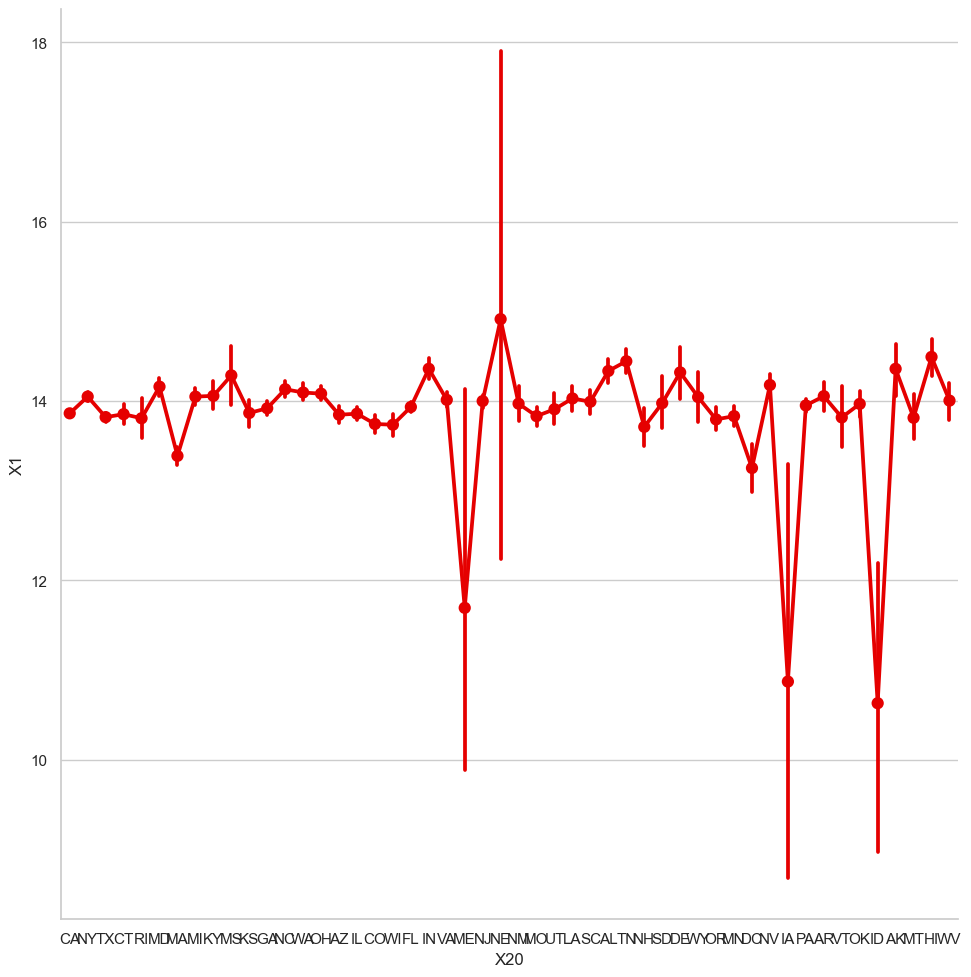

```python
sns.set(style="whitegrid")
g = sns.PairGrid(data=df, x_vars=['X20'], y_vars='X1', height=10)
g.map(sns.pointplot, color=sns.xkcd_rgb["red"])
```

#### Some states have a greater X1 difference but the distribution looks like these could be outliers. Drop column because distribution seems unhelpful.

```python
df = df.drop(['X20'], axis =1)
```

### X21

```python
df['X21'].info()
```

```
<class 'pandas.core.series.Series'>
Int64Index: 338990 entries, 0 to 399999
Series name: X21
Non-Null Count   Dtype
--------------   -----
338989 non-null  float64
dtypes: float64(1)
memory usage: 5.2 MB
```

```python
df['X21'].describe()
```

```
count    338989.000000
mean         16.997242
std           7.697223
min           0.000000
25%          11.250000
50%          16.700000
75%          22.500000
max          39.990000
Name: X21, dtype: float64
```

#### replace 1 null with mean

```python
mean_value=df['X21'].mean()
df['X21'].fillna(value=mean_value, inplace=True)
```

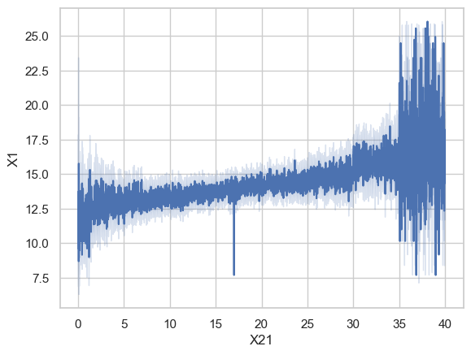

```python
sns.lineplot(x="X21", y="X1", data=df)
plt.show()
```

### dummy variabes: is_ratio (8 variables), drop X21

#### create bins for ratio. make cleaner.

```python
bins = [0, 5, 10, 15, 20, 25, 30, 35, 40]
labels = ['is_ratio5', 'is_ratio10','is_ratio15',
         'is_ratio20','is_ratio25','is_ratio30',
         'is_ratio35','is_ratio40']
df['ratio_categories'] = pd.cut(df['X21'], bins=bins, labels=labels)

dummy_df = pd.get_dummies(df['ratio_categories'])
df = pd.concat([df, dummy_df], axis=1)
df = df.drop('ratio_categories', axis=1)
df = df.drop(['X21'], axis =1)
```

### X22

```python
df['X22'].info()
```

```
<class 'pandas.core.series.Series'>
Int64Index: 338990 entries, 0 to 399999
Series name: X22
Non-Null Count   Dtype
--------------   -----
338989 non-null  float64
dtypes: float64(1)
memory usage: 5.2 MB
```

#### one null, float. replace with mean

```python
df['X22'].describe()
```

```
count    338989.000000
mean          0.274286
std           0.779294
min           0.000000
25%           0.000000
50%           0.000000
75%           0.000000
max          29.000000
Name: X22, dtype: float64
```

```python
mean_value=df['X22'].mean()
df['X22'].fillna(value=mean_value, inplace=True)
```

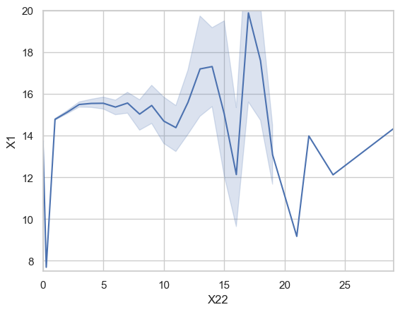

```python
sns.lineplot(x="X22", y="X1", data=df)
plt.xlim(0, 29)
plt.ylim(7.5, 20)
plt.show()
```

### X23

```python
df['X23'].info()
```

```
<class 'pandas.core.series.Series'>
Int64Index: 338990 entries, 0 to 399999
Series name: X23
Non-Null Count   Dtype
--------------   -----
338989 non-null  object
dtypes: object(1)
memory usage: 5.2+ MB
```

```python
df['X23'].mode()
```

```
0    Oct-00
Name: X23, dtype: object
```

#### one null, string. replace with mode

```python
df['X23'].fillna(value="Oct-00", inplace=True)
```

```python
df['X23']
```

```
0         Feb-94
1         Oct-00
2         Jun-00
3         Jan-85
4         Dec-96
           ...
399995    Nov-03
399996    Oct-07
399997    Oct-04
399998    Mar-94
399999    Sep-10
Name: X23, Length: 338990, dtype: object
```

#### split date into month and year, for better EDA

```python
df[['month_creditOpened', 'year_creditOpened']] = df['X23'].str.split('-', expand=True)
df['year_creditOpened'] = df['year_creditOpened'].astype(int)
```

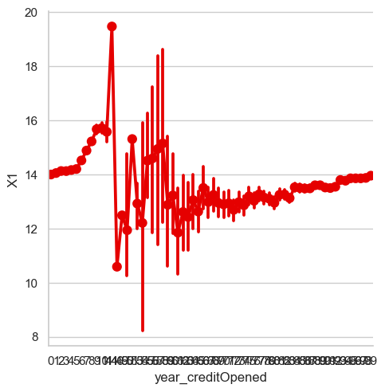

```python
sns.set(style="whitegrid")
g = sns.PairGrid(data=df, x_vars=['year_creditOpened'], y_vars='X1', height=5)
g.map(sns.pointplot, color=sns.xkcd_rgb["red"])
```

#### keep year as continious since the X1 shifts are all over

```python
df = df.drop(['X23'], axis =1)
df = df.drop(['month_creditOpened'], axis =1)
```

## X24

```python
df['X24'].info()
```

```
<class 'pandas.core.series.Series'>
Int64Index: 338990 entries, 0 to 399999
Series name: X24
Non-Null Count   Dtype
--------------   -----
338989 non-null  float64
dtypes: float64(1)
memory usage: 5.2 MB
```

```python
df['X24'].mode()
```

```
0    0.0
Name: X24, dtype: float64
```

#### one null, float. replace with mode

```python
df['X24'] = df['X24'].fillna(value= 0, inplace=False)
df['X24'] = df['X24'].astype(int)
```

```python
df['X24'].unique()
```

```
array([0, 1, 2, 3, 4, 5, 6, 8, 7])
```

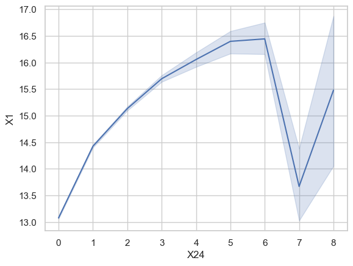

```python
sns.lineplot(x="X24", y="X1", data=df)
plt.show()
```

### dummy creation: is_inquiries_6orless, drop X24

```python
bins = [-1, 6]
labels = ['is_inquiries_6orless']
df['inquiry_categories'] = pd.cut(df['X24'], bins=bins, labels=labels)

dummy_df = pd.get_dummies(df['inquiry_categories'])
```

```python
df = pd.concat([df, dummy_df], axis=1)
df = df.drop('inquiry_categories', axis=1)
df = df.drop(['X24'], axis =1)
```

### X25

```python
df['X25'].info()
```

```
<class 'pandas.core.series.Series'>
Int64Index: 338990 entries, 0 to 399999
Series name: X25
Non-Null Count   Dtype
--------------   -----
153533 non-null  float64
dtypes: float64(1)
memory usage: 5.2 MB
```

```python
153533 / 338990
```

```
0.45291306528216174
```

### not enough data to belpful, drop

```python
df = df.drop(['X25'], axis =1)
```

## X26

```python
df['X26'].info()
```

```
<class 'pandas.core.series.Series'>
Int64Index: 338990 entries, 0 to 399999
Series name: X26
Non-Null Count  Dtype
--------------  -----
43400 non-null  float64
dtypes: float64(1)
memory usage: 5.2 MB
```

```python
43400/ 338990
```

```
0.1280273754388035
```

### not enough, drop

```python
df = df.drop(['X26'], axis =1)
```

## X27

```python
df['X27'].info()
```

```
<class 'pandas.core.series.Series'>
Int64Index: 338990 entries, 0 to 399999
Series name: X27
Non-Null Count   Dtype
--------------   -----
338989 non-null  float64
dtypes: float64(1)
memory usage: 5.2 MB
```

```python
df['X27'].mode()
```

```
0    9.0
Name: X27, dtype: float64
```

#### one null, float. replace with mode

```python
df['X27'] = df['X27'].fillna(value= 9, inplace=False)
df['X27'] = df['X27'].astype(int)
```

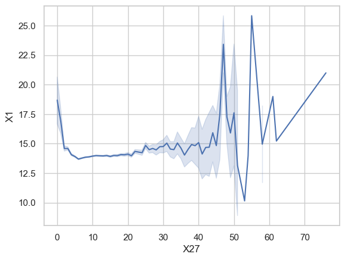

```python
sns.lineplot(x="X27", y="X1", data=df)
plt.show()
```

### X28

```python
df['X28'].info()
```

```
<class 'pandas.core.series.Series'>
Int64Index: 338990 entries, 0 to 399999
Series name: X28
Non-Null Count   Dtype
--------------   -----
338989 non-null  float64
dtypes: float64(1)
memory usage: 5.2 MB
```

```python
df['X28'].unique()
```

```
array([ 0.,  1.,  2.,  3.,  4.,  5.,  7.,  6.,  8., 54., 10., 11., 49.,
        9., 17., 13., 34., 21., 63., 40., 18., nan, 14.])
```

```python
df['X28'].mode()
```

```
0    0.0
Name: X28, dtype: float64
```

#### one null, float. replace with mode

```python
df['X28'] = df['X28'].fillna(value= 0, inplace=False)
df['X28'] = df['X28'].astype(int)
```

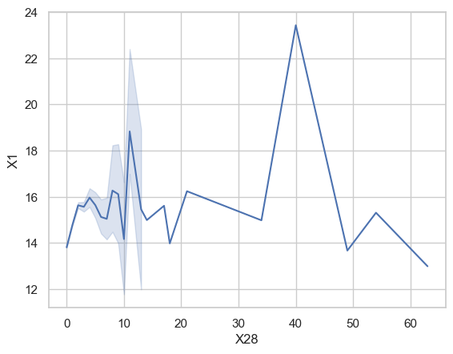

```python
sns.lineplot(x="X28", y="X1", data=df)
plt.show()
```

### X29

```python
df['X29'].info()
```

```
<class 'pandas.core.series.Series'>
Int64Index: 338990 entries, 0 to 399999
Series name: X29
Non-Null Count   Dtype
--------------   -----
338989 non-null  float64
dtypes: float64(1)
memory usage: 5.2 MB
```

```python
df['X29'].describe()
```

```
count    3.389890e+05
mean     1.597434e+04
std      1.976517e+04
min      0.000000e+00
25%      6.462000e+03
50%      1.178200e+04
75%      2.023300e+04
max      2.568995e+06
Name: X29, dtype: float64
```

```python
df['X29'].mode()
```

```
0    0.0
Name: X29, dtype: float64
```

#### one null, float. replace with mode

```python
df['X29'] = df['X29'].fillna(value= 0, inplace=False)
```

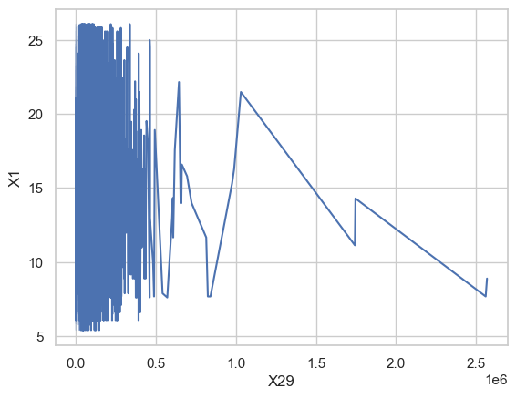

```python
sns.lineplot(x="X29", y="X1", data=df)
plt.show()
```

### X30

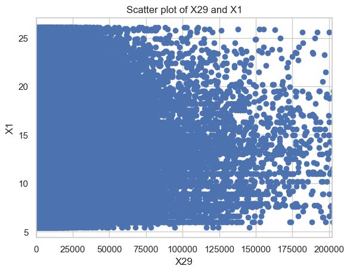

```python
plt.scatter(df['X29'], df['X1'])

plt.xlabel('X29')
plt.ylabel('X1')
plt.title('Scatter plot of X29 and X1')
plt.xlim(left=0, right=2.020900e+05)

# Show the plot
plt.show()
```

```python
df['X30'].info()
```

```
<class 'pandas.core.series.Series'>
Int64Index: 338990 entries, 0 to 399999
Series name: X30
Non-Null Count   Dtype
--------------   -----
338765 non-null  float64
dtypes: float64(1)
memory usage: 5.2 MB
```

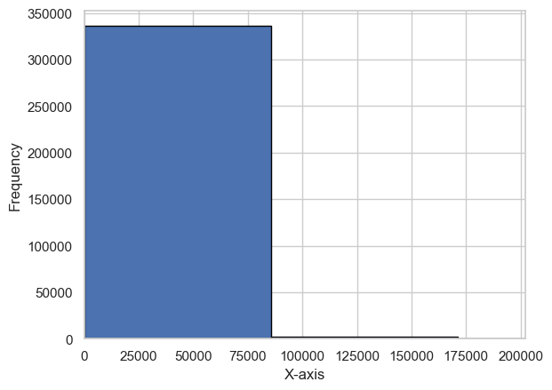

```python
plt.hist(df['X29'], bins=30, edgecolor='black')

# Label the axes
plt.xlabel('X-axis')
plt.ylabel('Frequency')
plt.xlim(left=0, right=2.020900e+05)


# Show the plot
plt.show()
```

```python
338765 / 338990
```

```
0.9993362636065961
```

### less than 5% missing, interpolate, can do because it is numerical

```python
df['X30']= df['X30'].interpolate()
```

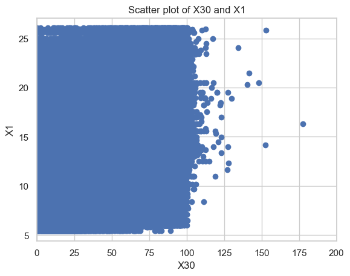

```python
plt.scatter(df['X30'], df['X1'])

plt.xlabel('X30')
plt.ylabel('X1')
plt.title('Scatter plot of X30 and X1')
plt.xlim(left=0, right=200)

# Show the plot
plt.show()
```

### X31

```python
df['X31'].info()
```

```
<class 'pandas.core.series.Series'>
Int64Index: 338990 entries, 0 to 399999
Series name: X31
Non-Null Count   Dtype
--------------   -----
338989 non-null  float64
dtypes: float64(1)
memory usage: 5.2 MB
```

```python
df['X31'].unique()
```

```
array([ 42.,   7.,  17.,  31.,  40.,  25.,  11.,  23.,  19.,   9.,  33.,
        51.,   8.,  16.,  37.,  49.,   6.,  39.,  14.,  27.,  21.,   2.,
        26.,  20.,  29.,  38.,  13.,  12.,   4.,  22.,  28.,  24.,  18.,
        32.,  36.,  60.,  15.,   5.,  41.,   3.,  34.,  10.,  43.,  30.,
        35.,  55.,  63.,  44.,  76.,  48.,  47.,  45.,  46.,  53.,  64.,
        61.,  59.,  52.,  54.,  50.,  62.,  58.,  56.,  66.,  57.,  65.,
        67.,  68.,  73.,  70.,  71.,  69.,  75.,  80.,  90.,  81.,  78.,
        72.,  87.,  77.,  79.,  91.,  99.,  74.,  82.,  88.,  98.,  84.,
        83., 105.,  86.,  85.,  89., 102.,  94.,  nan, 118., 116., 117.,
        93.,  92.,  97.])
```

### one null, float. replace with mode

```python
df['X31'].mode()
```

```
0    21.0
Name: X31, dtype: float64
```

```python
df['X31'] = df['X31'].replace(np.nan, 21)
df['X31'] = df['X31'].astype(int)
```

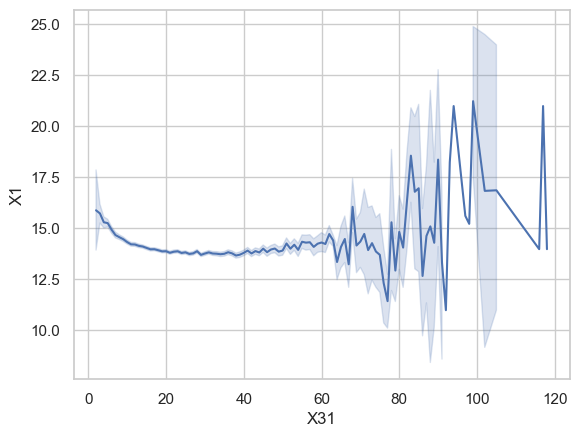

```python
sns.lineplot(x="X31", y="X1", data=df)
plt.show()
```

### X32

```python
df['X32'].info()
```

```
<class 'pandas.core.series.Series'>
Int64Index: 338990 entries, 0 to 399999
Series name: X32
Non-Null Count   Dtype
--------------   -----
338989 non-null  object
dtypes: object(1)
memory usage: 5.2+ MB
```

```python
df['X32'].unique()
```

```
array(['f', 'w', nan], dtype=object)
```

#### one null, string. replace with mode

```python
df['X32'].mode()
```

```
0    f
Name: X32, dtype: object
```

```python
df['X32'] = df['X32'].fillna(value= 'f', inplace=False)
```

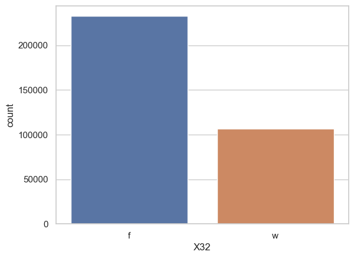

```python
sns.countplot(x='X32', data=df)
plt.show()
```

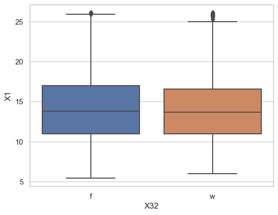

```python
sns.boxplot(x='X32', y='X1', data=df)
plt.show()
```

### dummy variable: is_initialstatus_f, drop X32

```python
df['is_initialstatus_f'] = df['X32'].apply(lambda x: 1 if
                                           x == 'f' else 0)
```

```python
df = df.drop(['X32'], axis =1)
```

```python
df['is_initialstatus_f'].info()
```

```
<class 'pandas.core.series.Series'>
Int64Index: 338990 entries, 0 to 399999
Series name: is_initialstatus_f
Non-Null Count   Dtype
--------------   -----
338990 non-null  int64
dtypes: int64(1)
memory usage: 5.2 MB
```

### X12

#### had to do at end because KNN needs standardization, so need to convert all categorical to binar/ dummy variables.

```python
df['X12'].info()
```

```
<class 'pandas.core.series.Series'>
Int64Index: 338990 entries, 0 to 399999
Series name: X12
Non-Null Count   Dtype
--------------   -----
287030 non-null  object
dtypes: object(1)
memory usage: 5.2+ MB
```

```python
287030 / 338990
```

```
0.8467211422165846
```

```python
df.isnull().sum()
```

```
X1                          0
X9                          0
X12                     51960
X13                         0
X22                         0
                        ...
is_ratio35                  0
is_ratio40                  0
year_creditOpened           0
is_inquiries_6orless        0
is_initialstatus_f          0
Length: 72, dtype: int64
```

### create dummy: X12_

```python
from sklearn.impute import KNNImputer
cat_variables = df[['X12']]
cat_dummies = pd.get_dummies(cat_variables, drop_first=True)
```

```python
df = df.drop(['X12'], axis=1)
df = pd.concat([df, cat_dummies], axis=1)
df.head()
```

|  | X1 | X9 | X13 | X22 | X27 | X28 | X29 | X30 | X31 | loanrequest_1000 | ... | is_ratio35 | is_ratio40 | year_creditOpened | is_inquiries_6orless | is_initialstatus_f | X12_MORTGAGE | X12_NONE | X12_OTHER | X12_OWN | X12_RENT |
| --- | --- | --- | --- | --- | --- | --- | --- | --- | --- | --- | --- | --- | --- | --- | --- | --- | --- | --- | --- | --- | --- |
| 0 | 11.89 | 9 | 85000.0 | 0.0 | 10 | 0 | 28854.0 | 52.1 | 42 | 0 | ... | 0 | 0 | 94 | 1 | 1 | 0 | 0 | 0 | 0 | 1 |
| 1 | 10.71 | 10 | 65000.0 | 0.0 | 7 | 0 | 33623.0 | 76.7 | 7 | 0 | ... | 0 | 0 | 0 | 1 | 1 | 0 | 0 | 0 | 0 | 1 |
| 2 | 16.99 | 18 | 70000.0 | 0.0 | 10 | 0 | 19878.0 | 66.3 | 17 | 0 | ... | 0 | 0 | 0 | 1 | 1 | 0 | 0 | 0 | 0 | 1 |
| 3 | 13.11 | 12 | 54000.0 | 0.0 | 5 | 0 | 2584.0 | 40.4 | 31 | 0 | ... | 0 | 0 | 85 | 1 | 1 | 0 | 0 | 0 | 1 | 0 |
| 4 | 13.57 | 13 | 32000.0 | 0.0 | 14 | 0 | 3511.0 | 25.6 | 40 | 0 | ... | 0 | 0 | 96 | 1 | 1 | 0 | 0 | 0 | 0 | 1 |

5 rows × 76 columns

### Standardize. Important for KNN and Model Engineering.

#### In practice it is nearly always advantageous to apply pre-processing transformations to the input data before it is presented to a network. Similarly, the outputs of the network are often post-processed to give the required output values.

#### — Page 296, Neural Networks for Pattern Recognition, 1995.

```python
from sklearn.preprocessing import MinMaxScaler
```

### use different Scaler for target variable

```python
# fit a Scaler on the 'X1' column only
x1scaler = MinMaxScaler()
x1scaler.fit(df[['X1']])
df['X1'] = x1scaler.transform(df[['X1']])
```

```python
scaler = MinMaxScaler()
feature_data = [col for col in df.columns if col != 'X1']
df[feature_data] = scaler.fit_transform(df[feature_data])
df.head()
```

|  | X1 | X9 | X13 | X22 | X27 | X28 | X29 | X30 | X31 | loanrequest_1000 | ... | is_ratio35 | is_ratio40 | year_creditOpened | is_inquiries_6orless | is_initialstatus_f | X12_MORTGAGE | X12_NONE | X12_OTHER | X12_OWN | X12_RENT |
| --- | --- | --- | --- | --- | --- | --- | --- | --- | --- | --- | --- | --- | --- | --- | --- | --- | --- | --- | --- | --- | --- |
| 0 | 0.313469 | 0.235294 | 0.010938 | 0.0 | 0.131579 | 0.0 | 0.011232 | 0.058388 | 0.344828 | 0.0 | ... | 0.0 | 0.0 | 0.949495 | 1.0 | 1.0 | 0.0 | 0.0 | 0.0 | 0.0 | 1.0 |
| 1 | 0.256298 | 0.264706 | 0.008270 | 0.0 | 0.092105 | 0.0 | 0.013088 | 0.085958 | 0.043103 | 0.0 | ... | 0.0 | 0.0 | 0.000000 | 1.0 | 1.0 | 0.0 | 0.0 | 0.0 | 0.0 | 1.0 |
| 2 | 0.560562 | 0.500000 | 0.008937 | 0.0 | 0.131579 | 0.0 | 0.007738 | 0.074302 | 0.129310 | 0.0 | ... | 0.0 | 0.0 | 0.000000 | 1.0 | 1.0 | 0.0 | 0.0 | 0.0 | 0.0 | 1.0 |
| 3 | 0.372578 | 0.323529 | 0.006803 | 0.0 | 0.065789 | 0.0 | 0.001006 | 0.045276 | 0.250000 | 0.0 | ... | 0.0 | 0.0 | 0.858586 | 1.0 | 1.0 | 0.0 | 0.0 | 0.0 | 1.0 | 0.0 |
| 4 | 0.394864 | 0.352941 | 0.003868 | 0.0 | 0.184211 | 0.0 | 0.001367 | 0.028690 | 0.327586 | 0.0 | ... | 0.0 | 0.0 | 0.969697 | 1.0 | 1.0 | 0.0 | 0.0 | 0.0 | 0.0 | 1.0 |

5 rows × 76 columns

## KNN Imputation for X12

```python
from sklearn.impute import KNNImputer
imputer = KNNImputer(n_neighbors=5)
df = pd.DataFrame(imputer.fit_transform(df),columns = df.columns)
```

```python
df.isnull().sum()
```

```
X1              0
X9              0
X13             0
X22             0
X27             0
               ..
X12_MORTGAGE    0
X12_NONE        0
X12_OTHER       0
X12_OWN         0
X12_RENT        0
Length: 76, dtype: int64
```

#### nulls were replaced succesfully

## Final Dataframe.

Everything is continuous or in binary format. We can proceed to model engineering.

```python
df.head()
```

|  | X1 | X9 | X13 | X22 | X27 | X28 | X29 | X30 | X31 | loanrequest_1000 | ... | is_ratio35 | is_ratio40 | year_creditOpened | is_inquiries_6orless | is_initialstatus_f | X12_MORTGAGE | X12_NONE | X12_OTHER | X12_OWN | X12_RENT |
| --- | --- | --- | --- | --- | --- | --- | --- | --- | --- | --- | --- | --- | --- | --- | --- | --- | --- | --- | --- | --- | --- |
| 0 | 0.313469 | 0.235294 | 0.010938 | 0.0 | 0.131579 | 0.0 | 0.011232 | 0.058388 | 0.344828 | 0.0 | ... | 0.0 | 0.0 | 0.949495 | 1.0 | 1.0 | 0.0 | 0.0 | 0.0 | 0.0 | 1.0 |
| 1 | 0.256298 | 0.264706 | 0.008270 | 0.0 | 0.092105 | 0.0 | 0.013088 | 0.085958 | 0.043103 | 0.0 | ... | 0.0 | 0.0 | 0.000000 | 1.0 | 1.0 | 0.0 | 0.0 | 0.0 | 0.0 | 1.0 |
| 2 | 0.560562 | 0.500000 | 0.008937 | 0.0 | 0.131579 | 0.0 | 0.007738 | 0.074302 | 0.129310 | 0.0 | ... | 0.0 | 0.0 | 0.000000 | 1.0 | 1.0 | 0.0 | 0.0 | 0.0 | 0.0 | 1.0 |
| 3 | 0.372578 | 0.323529 | 0.006803 | 0.0 | 0.065789 | 0.0 | 0.001006 | 0.045276 | 0.250000 | 0.0 | ... | 0.0 | 0.0 | 0.858586 | 1.0 | 1.0 | 0.0 | 0.0 | 0.0 | 1.0 | 0.0 |
| 4 | 0.394864 | 0.352941 | 0.003868 | 0.0 | 0.184211 | 0.0 | 0.001367 | 0.028690 | 0.327586 | 0.0 | ... | 0.0 | 0.0 | 0.969697 | 1.0 | 1.0 | 0.0 | 0.0 | 0.0 | 0.0 | 1.0 |

5 rows × 76 columns

# Model Engineering

```python
X,y = df.drop(['X1'],axis =1), df['X1']
```

```python
SEED=1
train_X, test_X, train_y, test_y = train_test_split(X, y, train_size = 0.8,
                                                    test_size= 0.2, random_state= SEED)
```

## Standardize

Already done above, when I ran KNN a the end of Feature Engineering.

## Feature Importance

```python
from sklearn.model_selection import train_test_split
from sklearn.linear_model import LinearRegression
from sklearn.linear_model import LogisticRegression
from sklearn.tree import DecisionTreeRegressor
from sklearn.ensemble import RandomForestRegressor
from sklearn.svm import SVR
from sklearn.ensemble import GradientBoostingRegressor
from sklearn.neural_network import MLPRegressor
from sklearn.metrics import mean_squared_error, make_scorer
from sklearn.model_selection import cross_val_score
from sklearn.ensemble import RandomForestClassifier
from sklearn.preprocessing import LabelEncoder
from sklearn.inspection import permutation_importance
```

```python
from sklearn.ensemble import RandomForestClassifier

model = RandomForestRegressor(n_estimators=150)
model.fit(train_X, train_y)
```

```
RandomForestRegressor(n_estimators=150)
```

```python
# exclude X1, target variable
feature_names = df.columns[1:]
```

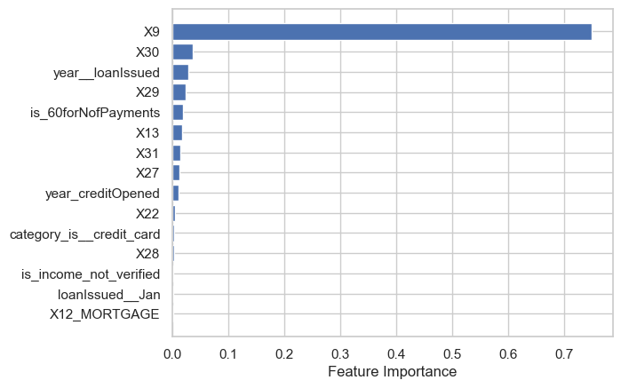

```python
n = 15
sort = model.feature_importances_.argsort()
top_n = sort[-n:]
plt.barh(feature_names[top_n], model.feature_importances_[top_n])
plt.xlabel("Feature Importance")
```

### Important to keep in mind. X9 is by far the most important feature, which I kept. All of these feartures are in the model. For now, keep all of them.

# Models

### Decision Tree Regression

```python
dt_regressor = DecisionTreeRegressor(max_depth=8,
                           min_samples_leaf=0.13,
                           random_state=0)
dt_regressor.fit(train_X, train_y)
y_pred = dt_regressor.predict(test_X)
rmse = np.sqrt(mean_squared_error(test_y, y_pred))
print("Decision Tree Regression RMSE:", rmse)
```

```
Decision Tree Regression RMSE: 0.11777481761087577
```

### Linear Regression

```python
regressor = LinearRegression()
regressor.fit(train_X, train_y)
y_pred = regressor.predict(test_X)
rmse = np.sqrt(mean_squared_error(test_y, y_pred))
print("Linear Regression RMSE:", rmse)
```

```
Linear Regression RMSE: 0.09861631827744195
```

### Random Forest Regression

```python
rf_regressor = RandomForestRegressor(random_state=0)
rf_regressor.fit(train_X, train_y)
y_pred = rf_regressor.predict(test_X)
rmse = np.sqrt(mean_squared_error(test_y, y_pred))
print("Random Forest Regression RMSE:", rmse)
```

```
Random Forest Regression RMSE: 0.08632292066362385
```

### Gradient Boosting Regression

```python
gb_regressor = GradientBoostingRegressor(random_state=0)
gb_regressor.fit(train_X, train_y)
y_pred = gb_regressor.predict(test_X)
rmse = np.sqrt(mean_squared_error(test_y, y_pred))
print("Gradient Boosting Regression RMSE:", rmse)
```

```
Gradient Boosting Regression RMSE: 0.09033426729501523
```

### I chose Random Forest Regression. It had the smallest and best RMSE of the models I ran: 0.08632.

## Check Overfitting/ Underfitting

##### find CV RMSE

```python
scorer = make_scorer(mean_squared_error, greater_is_better=False)
```

```python
cv_scores = cross_val_score(rf_regressor, X, y, scoring=scorer, cv=5)
cv_rmse = np.sqrt(-cv_scores).mean()
print("Random Forest Regression RMSE:", cv_rmse)
```

```
Random Forest Regression RMSE: 0.10049295711935113
```

#### According to the RMSE scores, there is neither Overfitting/ Underfitting. The CV RMSE is only .01 greater + both values are small. No need to fix. 0.10049 - 0.08632 = 0.01417.

### Hyperparameter Tuning

```python
#!pip3 install optuna
#!pip3 install lightgbm
```

# Clean test dataset to match train dataset.

```python
dftest = pd.read_csv('/Users/ankitanambiar/Desktop/Data Mining/Assignment_3/Loan_Prediction/Holdout for Testing.csv')
dftest.head()
```

|  | X1 | X2 | X3 | X4 | X5 | X6 | X7 | X8 | X9 | X10 | ... | X23 | X24 | X25 | X26 | X27 | X28 | X29 | X30 | X31 | X32 |
| --- | --- | --- | --- | --- | --- | --- | --- | --- | --- | --- | --- | --- | --- | --- | --- | --- | --- | --- | --- | --- | --- |
| 0 | NaN | 44409194 | 47416907 | $6,000 | $6,000 | $6,000 | 36 months | C | C5 | Electrician | ... | 2-Nov | 1 | 26.0 | NaN | 18 | 0 | 19861 | 64.50% | 33 | f |
| 1 | NaN | 44017917 | 47034722 | $24,000 | $24,000 | $24,000 | 36 months | A | A1 | Executive Assistant | ... | Dec-68 | 1 | NaN | NaN | 12 | 0 | 17001 | 26.20% | 36 | w |
| 2 | NaN | 44259158 | 47306871 | $35,000 | $35,000 | $35,000 | 36 months | C | C2 | District Sales Leader | ... | Oct-98 | 0 | NaN | NaN | 16 | 0 | 25797 | 49.90% | 33 | w |
| 3 | NaN | 44429213 | 47476932 | $10,000 | $10,000 | $10,000 | 60 months | D | D1 | pharmacy associate | ... | Feb-99 | 1 | NaN | 114.0 | 13 | 1 | 9586 | 43.80% | 21 | w |
| 4 | NaN | 44299188 | 47346901 | $24,000 | $24,000 | $24,000 | 60 months | B | B1 | Medical case manager | ... | 2-Dec | 0 | 48.0 | NaN | 27 | 0 | 31842 | 41.30% | 43 | w |

5 rows × 32 columns

```python
# X16
15/80000
```

```
0.0001875
```

```python
# X25
41296 / 80000
```

```
0.5162
```

```python
# X26
13839/ 80000
```

```
0.1729875
```

```python
dftest = dftest.drop(['X16'], axis =1)
dftest = dftest.drop(['X26'], axis =1)
dftest = dftest.drop(['X25'], axis =1)
```

```python
#X10
# not in df
dftest = dftest.drop(['X10'], axis =1)
```

```python
# convert X30 into float type, still in percentage
dftest['X30'] = dftest['X30'].str.rstrip("%").astype(float)

# convert X4, X5, X6 into float type from string, still in dollara
dftest['X4'] = dftest['X4'].replace('[\$,]', '', regex=True).astype(float)
dftest['X5'] = dftest['X5'].replace('[\$,]', '', regex=True).astype(float)
dftest['X6'] = dftest['X6'].replace('[\$,]', '', regex=True).astype(float)

# convert X7 into int type from string
dftest['X7'] = dftest['X7'].str.extract('(\d+)', expand=False)
dftest['X7'] = dftest['X7'].astype(float)
```

```python
bins = [0, 1000, 5000, 10000, 15000, 20000, 25000, 28000]
labels = ['loanrequest_1000', 'loanrequest_5000', 'loanrequest_10000', 'loanrequest_15000',
         'loanrequest_20000', 'loanrequest_25000', 'loanrequest_28000']
dftest['loanrequest_categories'] = pd.cut(dftest['X4'], bins=bins, labels=labels)
dummy_df = pd.get_dummies(dftest['loanrequest_categories'])
dftest = pd.concat([dftest, dummy_df], axis=1)
dftest = dftest.drop('loanrequest_categories', axis=1)
```

```python
dftest['%_funded'] = dftest['X5'] / dftest['X4'] * 100
```

```python
bins = [0, 5000, 15000, 20000, 25000, 28000, 30000]
labels = ['ivfunded_5000', 'ivfunded_15000', 'ivfunded_20000',
          'ivfunded_25000','ivfunded_28000', 'ivfunded_30000']
dftest['ivfunded_categories'] = pd.cut(dftest['X6'], bins=bins, labels=labels)
dummy_df = pd.get_dummies(dftest['ivfunded_categories'])
dftest = pd.concat([dftest, dummy_df], axis=1)
dftest = dftest.drop('ivfunded_categories', axis=1)
```

```python
dftest = dftest.drop(['X4'], axis =1)
dftest['%_inv_funded'] = dftest['X6'] / dftest['X5'] * 100
```

```python
bins = [0, 20, 40, 60, 80, 100]
labels = ['%_inv_funded_20', '%_inv_funded_40', '%_inv_funded_60',
         '%_inv_funded_80', '%_inv_funded_100']
dftest['%_inv_funded_categories'] = pd.cut(dftest['%_inv_funded'], bins=bins, labels=labels)
dummy_df = pd.get_dummies(dftest['%_inv_funded_categories'])
dftest = pd.concat([dftest, dummy_df], axis=1)
dftest = dftest.drop('%_inv_funded_categories', axis=1)
```

```python
dftest = dftest.drop(['%_inv_funded'], axis =1)
dftest = dftest.drop(['X6'], axis =1)
dftest = dftest.drop(['X5'], axis =1)
```

```python
dftest['is_60forNofPayments'] = dftest['X7'].apply(lambda x: 1 if x == 60.0 else 0)
dftest = dftest.drop(['X7'], axis =1)
dftest = dftest.drop(['X8'], axis=1)
```

```python
dftest = dftest.replace({'X11': {'< 1 year':0, '1 year' :1, '10+ years':10, '6 years':6, '9 years':9, '3 years':3,
       '5 years':5, '2 years':2, '4 years':4, '8 years':8, '7 years':7
                             }})
dftest['X11'] = dftest['X11'].interpolate()

bins = [0, 6]
labels = ['is_in_early-career']
dftest['career_age_categories'] = pd.cut(dftest['X11'], bins=bins, labels=labels)

dummy_df = pd.get_dummies(dftest['career_age_categories'])
dftest = pd.concat([dftest, dummy_df], axis=1)
dftest = dftest.drop('career_age_categories', axis=1)

dftest = dftest.drop('X11', axis=1)
```

```python
cat_variables = dftest[['X14']]
cat_dummies = pd.get_dummies(cat_variables, prefix=['is_'])

dftest = pd.concat([dftest, cat_dummies], axis=1)
dftest = dftest.rename(columns={'is__VERIFIED - income': 'is_income_verified',
                        'is__VERIFIED - income source': 'is_income_source_verified',
                        'is__not verified': 'is_income_not_verified'
                       })

dftest = dftest.drop('X14', axis=1)
```

```python
def convert_date(date):
    parts = date.split("-")
    if len(parts[0]) == 2:
        return pd.to_datetime(date, format='%d-%b', errors='coerce').strftime('%B-%d')
    else:
        return pd.to_datetime(date, format='%b-%d', errors='coerce').strftime('%B-%d')

dftest['X15'] = dftest['X15'].apply(convert_date)
```

```python
dftest[['month_loanIssued', 'year__loanIssued']] = dftest['X15'].str.split('-', expand=True)
dftest['year__loanIssued'] = dftest['year__loanIssued'].astype(int)

cat_variables = dftest[['month_loanIssued']]
cat_dummies = pd.get_dummies(cat_variables, prefix=['loanIssued_'])
dftest = pd.concat([dftest, cat_dummies], axis=1)
```

```python
dftest = dftest.drop(['X15'], axis =1)
dftest = dftest.drop(['month_loanIssued'], axis =1)
```

```python
cat_variables = dftest[['X17']]
cat_dummies = pd.get_dummies(cat_variables, prefix=['category_is_'])
dftest = pd.concat([dftest, cat_dummies], axis=1)
```

```python
dftest = dftest.drop(['X17'], axis =1)
dftest = dftest.drop(['X18'], axis =1)
dftest = dftest.drop(['X19'], axis =1)
dftest = dftest.drop(['X20'], axis =1)
```

```python
bins = [0, 5, 10, 15, 20, 25, 30, 35, 40]
labels = ['is_ratio5', 'is_ratio10','is_ratio15',
         'is_ratio20','is_ratio25','is_ratio30',
         'is_ratio35','is_ratio40']
dftest['ratio_categories'] = pd.cut(dftest['X21'], bins=bins, labels=labels)

dummy_df = pd.get_dummies(dftest['ratio_categories'])
dftest = pd.concat([dftest, dummy_df], axis=1)
dftest = dftest.drop('ratio_categories', axis=1)
```

```python
def convert_date(date):
    parts = date.split("-")
    if len(parts[0]) == 2:
        converted = pd.to_datetime(date, format='%d-%b', errors='coerce')
    else:
        converted = pd.to_datetime(date, format='%b-%y', errors='coerce')
    if pd.isna(converted):
        return None
    return converted.strftime('%B-%y')

dftest['X23'] = dftest['X23'].apply(convert_date)
```

```python
dftest[['month_creditOpened', 'year_creditOpened']] = dftest['X23'].str.split('-', expand=True)
```

```python
dftest['year_creditOpened'] = dftest['year_creditOpened'].astype(float)
dftest['year_creditOpened'] = dftest['year_creditOpened'].interpolate()
dftest['year_creditOpened'].mode()
dftest['year_creditOpened'].fillna(value=0, inplace=True)
dftest['year_creditOpened'] = dftest['year_creditOpened'].astype(int)
```

```python
dftest = dftest.drop(['X23'], axis =1)
dftest = dftest.drop(['month_creditOpened'], axis =1)
```

```python
dftest = dftest.drop(['X21'], axis =1)
```

```python
bins = [-1, 6]
labels = ['is_inquiries_6orless']
dftest['inquiry_categories'] = pd.cut(dftest['X24'], bins=bins, labels=labels)

dummy_df = pd.get_dummies(dftest['inquiry_categories'])
dftest = pd.concat([dftest, dummy_df], axis=1)
dftest = dftest.drop('inquiry_categories', axis=1)
```

```python
dftest = dftest.drop(['X24'], axis =1)

dftest['X30']= dftest['X30'].interpolate()

dftest['is_initialstatus_f'] = dftest['X32'].apply(lambda x: 1 if x == 'f' else 0)
```

```python
dftest = dftest.drop(['X32'], axis =1)
```

```python
dftest['X12_OTHER'] = 0
```

```python
dftest['X12_NONE'] = 0
```

```python
dftest = dftest.drop(['X2'], axis =1)
dftest = dftest.drop(['X3'], axis =1)
dftest = dftest.drop(['X1'], axis =1)
```

```python
dftest = dftest.replace({'X9': {'A1': 1, 'A2': 2, 'A3': 3, 'A4': 4,'A5': 5,
                        'B1': 6, 'B2': 7, 'B3': 8, 'B4': 9,'B5': 10,
                        'C1': 11, 'C2': 12, 'C3': 13, 'C4': 14,'C5': 15,
                        'D1': 16, 'D2': 17, 'D3': 18, 'D4': 19,'D5': 20,
                        'E1': 21, 'E2': 22, 'E3': 23, 'E4': 24,'E5':25,
                        'F1': 26, 'F2': 27, 'F3': 28, 'F4': 29,'F5':30,
                        'G1': 31, 'G2': 32, 'G3': 33, 'G4': 34,'G5':35
                       }})
```

```python
dftest['category_is__educational'] = 0
dftest['loanIssued__Apr'] = 0
dftest['loanIssued__Aug'] = 0
dftest['loanIssued__Dec'] = 0
dftest['loanIssued__Jul'] = 0
dftest['loanIssued__Jun'] = 0
dftest['loanIssued__May'] = 0
dftest['loanIssued__Nov'] = 0
dftest['loanIssued__Oct'] = 0
dftest['loanIssued__Sep'] = 0
```

```python
dftest = dftest.rename(columns={'loanIssued__February': 'loanIssued__Feb', 'loanIssued__January': 'loanIssued__Jan',
                               'loanIssued__March': 'loanIssued__Mar'})
```

```python
columnsend= ['X9', 'X13', 'X22', 'X27', 'X28', 'X29', 'X30', 'X31',
       'loanrequest_1000', 'loanrequest_5000', 'loanrequest_10000',
       'loanrequest_15000', 'loanrequest_20000', 'loanrequest_25000',
       'loanrequest_28000', '%_funded', 'ivfunded_5000', 'ivfunded_15000',
       'ivfunded_20000', 'ivfunded_25000', 'ivfunded_28000', 'ivfunded_30000',
       '%_inv_funded_20', '%_inv_funded_40', '%_inv_funded_60',
       '%_inv_funded_80', '%_inv_funded_100', 'is_60forNofPayments',
       'is_in_early-career', 'is_income_verified', 'is_income_source_verified',
       'is_income_not_verified', 'year__loanIssued', 'loanIssued__Apr',
       'loanIssued__Aug', 'loanIssued__Dec', 'loanIssued__Feb',
       'loanIssued__Jan', 'loanIssued__Jul', 'loanIssued__Jun',
       'loanIssued__Mar', 'loanIssued__May', 'loanIssued__Nov',
       'loanIssued__Oct', 'loanIssued__Sep', 'category_is__car',
       'category_is__credit_card', 'category_is__debt_consolidation',
       'category_is__educational', 'category_is__home_improvement',
       'category_is__house', 'category_is__major_purchase',
       'category_is__medical', 'category_is__moving', 'category_is__other',
       'category_is__renewable_energy', 'category_is__small_business',
       'category_is__vacation', 'category_is__wedding', 'is_ratio5',
       'is_ratio10', 'is_ratio15', 'is_ratio20', 'is_ratio25', 'is_ratio30',
       'is_ratio35', 'is_ratio40', 'year_creditOpened', 'is_inquiries_6orless',
       'is_initialstatus_f', 'X12_NONE', 'X12_OTHER']
```

```python
dftest['X12'].unique()
cat_variables = dftest[['X12']]
cat_dummies = pd.get_dummies(cat_variables, prefix=['X12_'])
dftest = pd.concat([dftest, cat_dummies], axis=1)
```

```python
dftest = dftest.drop(['X12'], axis =1)
```

```python
dftest = dftest.reindex(columns=['X9', 'X13', 'X22', 'X27', 'X28', 'X29', 'X30', 'X31',
       'loanrequest_1000', 'loanrequest_5000', 'loanrequest_10000',
       'loanrequest_15000', 'loanrequest_20000', 'loanrequest_25000',
       'loanrequest_28000', '%_funded', 'ivfunded_5000', 'ivfunded_15000',
       'ivfunded_20000', 'ivfunded_25000', 'ivfunded_28000', 'ivfunded_30000',
       '%_inv_funded_20', '%_inv_funded_40', '%_inv_funded_60',
       '%_inv_funded_80', '%_inv_funded_100', 'is_60forNofPayments',
       'is_in_early-career', 'is_income_verified', 'is_income_source_verified',
       'is_income_not_verified', 'year__loanIssued', 'loanIssued__Apr',
       'loanIssued__Aug', 'loanIssued__Dec', 'loanIssued__Feb',
       'loanIssued__Jan', 'loanIssued__Jul', 'loanIssued__Jun',
       'loanIssued__Mar', 'loanIssued__May', 'loanIssued__Nov',
       'loanIssued__Oct', 'loanIssued__Sep', 'category_is__car',
       'category_is__credit_card', 'category_is__debt_consolidation',
       'category_is__educational', 'category_is__home_improvement',
       'category_is__house', 'category_is__major_purchase',
       'category_is__medical', 'category_is__moving', 'category_is__other',
       'category_is__renewable_energy', 'category_is__small_business',
       'category_is__vacation', 'category_is__wedding', 'is_ratio5',
       'is_ratio10', 'is_ratio15', 'is_ratio20', 'is_ratio25', 'is_ratio30',
       'is_ratio35', 'is_ratio40', 'year_creditOpened', 'is_inquiries_6orless',
       'is_initialstatus_f', 'X12__MORTGAGE', 'X12_NONE', 'X12_OTHER', 'X12__OWN', 'X12__RENT'])
```

```python
dftest = dftest.rename(columns={'X12__MORTGAGE': 'X12_MORTGAGE', 'X12__RENT': 'X12_RENT',
                               'X12__OWN': 'X12_OWN'})
```

```python
dftest
```

|  | X9 | X13 | X22 | X27 | X28 | X29 | X30 | X31 | loanrequest_1000 | loanrequest_5000 | ... | is_ratio35 | is_ratio40 | year_creditOpened | is_inquiries_6orless | is_initialstatus_f | X12_MORTGAGE | X12_NONE | X12_OTHER | X12_OWN | X12_RENT |
| --- | --- | --- | --- | --- | --- | --- | --- | --- | --- | --- | --- | --- | --- | --- | --- | --- | --- | --- | --- | --- | --- |
| 0 | 15 | 68000.0 | 0 | 18 | 0 | 19861 | 64.5 | 33 | 0 | 0 | ... | 0 | 0 | 0 | 1 | 1 | 1 | 0 | 0 | 0 | 0 |
| 1 | 1 | 110480.0 | 0 | 12 | 0 | 17001 | 26.2 | 36 | 0 | 0 | ... | 0 | 0 | 68 | 1 | 0 | 0 | 0 | 0 | 0 | 1 |
| 2 | 12 | 86000.0 | 0 | 16 | 0 | 25797 | 49.9 | 33 | 0 | 0 | ... | 1 | 0 | 98 | 1 | 0 | 1 | 0 | 0 | 0 | 0 |
| 3 | 16 | 30000.0 | 0 | 13 | 1 | 9586 | 43.8 | 21 | 0 | 0 | ... | 1 | 0 | 99 | 1 | 0 | 0 | 0 | 0 | 0 | 1 |
| 4 | 6 | 82500.0 | 0 | 27 | 0 | 31842 | 41.3 | 43 | 0 | 0 | ... | 1 | 0 | 98 | 1 | 0 | 1 | 0 | 0 | 0 | 0 |
| ... | ... | ... | ... | ... | ... | ... | ... | ... | ... | ... | ... | ... | ... | ... | ... | ... | ... | ... | ... | ... | ... |
| 79995 | 2 | 50000.0 | 0 | 13 | 0 | 7185 | 47.9 | 15 | 0 | 0 | ... | 0 | 0 | 97 | 1 | 1 | 1 | 0 | 0 | 0 | 0 |
| 79996 | 22 | 92000.0 | 0 | 19 | 0 | 25151 | 51.3 | 38 | 0 | 0 | ... | 0 | 0 | 96 | 1 | 1 | 1 | 0 | 0 | 0 | 0 |
| 79997 | 19 | 70000.0 | 0 | 18 | 0 | 12161 | 37.1 | 36 | 0 | 0 | ... | 0 | 0 | 97 | 1 | 1 | 1 | 0 | 0 | 0 | 0 |
| 79998 | 12 | 80000.0 | 0 | 13 | 0 | 13031 | 76.7 | 23 | 0 | 1 | ... | 0 | 0 | 99 | 1 | 1 | 1 | 0 | 0 | 0 | 0 |
| 79999 | 10 | 78000.0 | 0 | 8 | 0 | 13773 | 93.7 | 26 | 0 | 0 | ... | 0 | 0 | 99 | 1 | 1 | 1 | 0 | 0 | 0 | 0 |

80000 rows × 75 columns

```python
scaler = MinMaxScaler()
dftest = pd.DataFrame(scaler.fit_transform(dftest), columns = dftest.columns)
dftest.head()
```

|  | X9 | X13 | X22 | X27 | X28 | X29 | X30 | X31 | loanrequest_1000 | loanrequest_5000 | ... | is_ratio35 | is_ratio40 | year_creditOpened | is_inquiries_6orless | is_initialstatus_f | X12_MORTGAGE | X12_NONE | X12_OTHER | X12_OWN | X12_RENT |
| --- | --- | --- | --- | --- | --- | --- | --- | --- | --- | --- | --- | --- | --- | --- | --- | --- | --- | --- | --- | --- | --- |
| 0 | 0.411765 | 0.007294 | 0.0 | 0.217949 | 0.000000 | 0.019026 | 0.349404 | 0.183544 | 0.0 | 0.0 | ... | 0.0 | 0.0 | 0.000000 | 1.0 | 1.0 | 1.0 | 0.0 | 0.0 | 0.0 | 0.0 |
| 1 | 0.000000 | 0.012176 | 0.0 | 0.141026 | 0.000000 | 0.016287 | 0.141928 | 0.202532 | 0.0 | 0.0 | ... | 0.0 | 0.0 | 0.686869 | 1.0 | 0.0 | 0.0 | 0.0 | 0.0 | 0.0 | 1.0 |
| 2 | 0.323529 | 0.009363 | 0.0 | 0.192308 | 0.000000 | 0.024713 | 0.270314 | 0.183544 | 0.0 | 0.0 | ... | 1.0 | 0.0 | 0.989899 | 1.0 | 0.0 | 1.0 | 0.0 | 0.0 | 0.0 | 0.0 |
| 3 | 0.441176 | 0.002928 | 0.0 | 0.153846 | 0.045455 | 0.009183 | 0.237270 | 0.107595 | 0.0 | 0.0 | ... | 1.0 | 0.0 | 1.000000 | 1.0 | 0.0 | 0.0 | 0.0 | 0.0 | 0.0 | 1.0 |
| 4 | 0.147059 | 0.008961 | 0.0 | 0.333333 | 0.000000 | 0.030504 | 0.223727 | 0.246835 | 0.0 | 0.0 | ... | 1.0 | 0.0 | 0.989899 | 1.0 | 0.0 | 1.0 | 0.0 | 0.0 | 0.0 | 0.0 |

5 rows × 75 columns

# test

```python
Xtest = dftest
```

```python
rf_regressor = RandomForestRegressor(random_state=0)
rf_regressor.fit(train_X, train_y)
y_pred = rf_regressor.predict(Xtest)
```

```python
pred_df = Xtest.copy()
```

```python
pred_df['y_pred'] = y_pred
```

```python
pred_df['y_pred'] = x1scaler.inverse_transform(pred_df[['y_pred']])
```

```python
pred_df['y_pred'] = pred_df['y_pred'].round(2)
pred_df['y_pred'] = pred_df['y_pred'].apply(lambda x: str(x) + '%')
```

```python
predicts = pd.DataFrame({
    "X1": pred_df['y_pred']
})
predicts
```

|  | X1 |
| --- | --- |
| 0 | 11.65% |
| 1 | 6.76% |
| 2 | 14.27% |
| 3 | 14.46% |
| 4 | 18.66% |
| ... | ... |
| 79995 | 12.93% |
| 79996 | 16.68% |
| 79997 | 12.65% |
| 79998 | 14.24% |
| 79999 | 11.7% |

80000 rows × 1 columns

```python
predicts.to_csv("PredictionsLoan.csv", index = False)
```

### Brief General Model Evaluation

The main 3 models I used and considered were linear regression, Decision Tree Regression, and Gradient Boosting Regression. First, there is linear regression. The model is simple. Being simple means it is easy to understand and easily run on computationally. However, it does not take into account potential outliers or potential correlation between features, which affects predictions. As for, Decision Tree Regression, the output is easily understood and does not need the data to be scaled. However, it takes a long time to run and also can lead to overfitting. Lastly, Gradient Boost Regression, had a lot of flexibility in dealing with both categorical and numerical values (although I did clean my data before). However, it took very long to run and can lead to overfitting.